# Conjunction Analysis

## Miss distance vs cumulative count plot

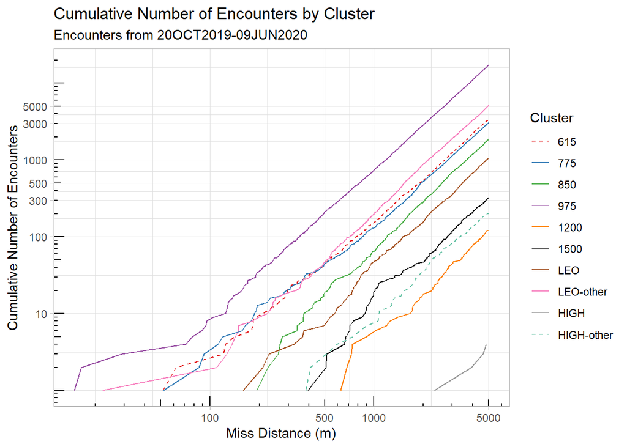

## Percent of Encounters by Country

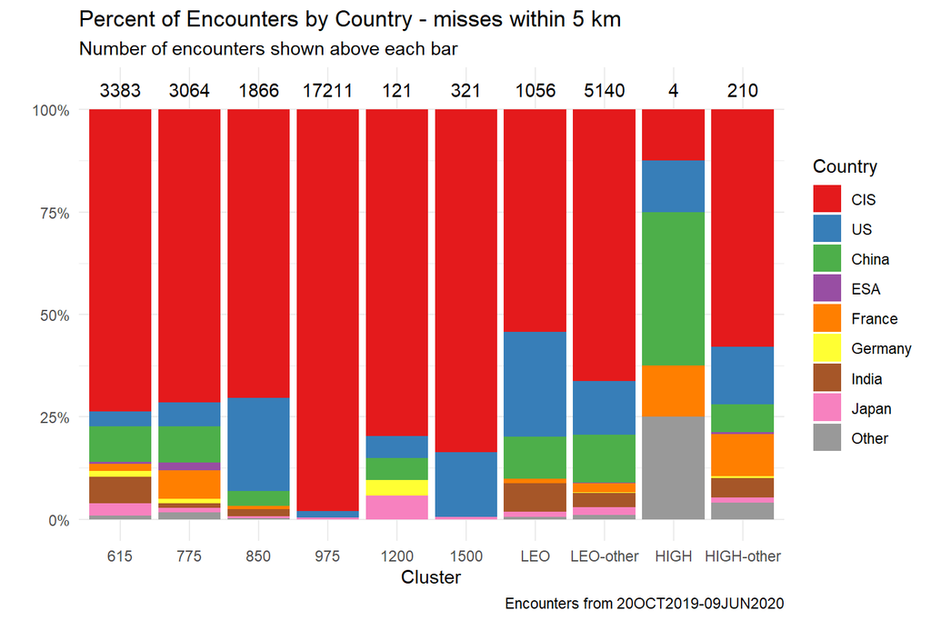

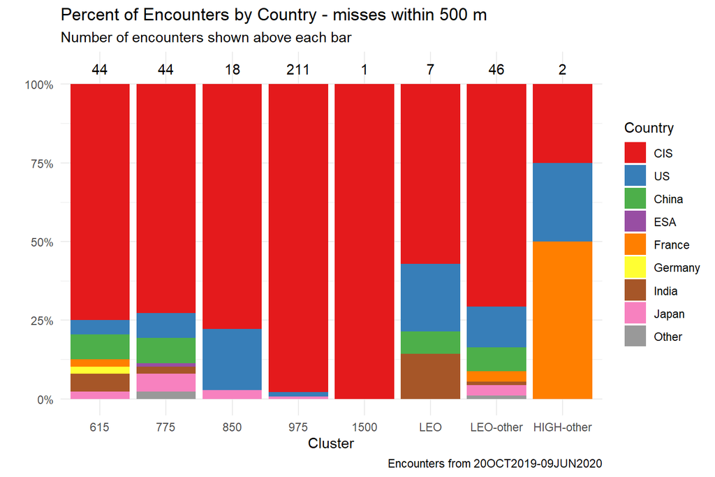

## Worst offender analysis– Method 1

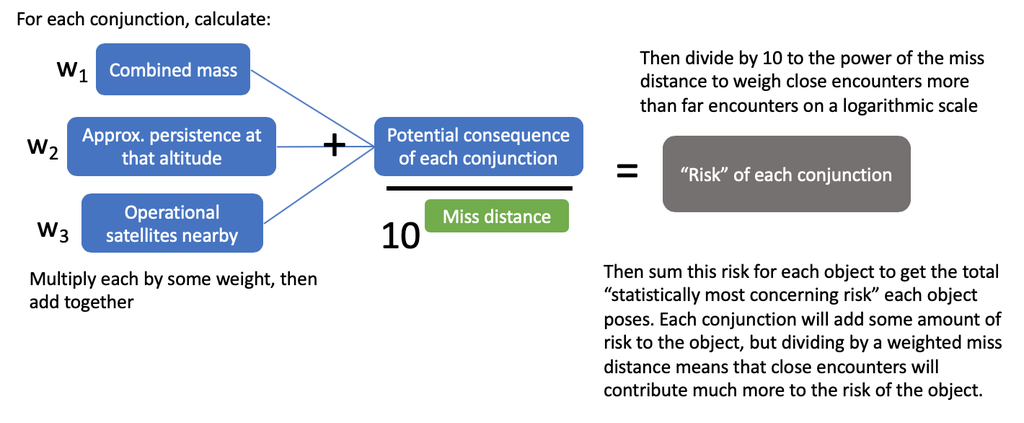

Graphical explanation of algorithm

Current list of top 50 objects with highest risk:

| noradId | name | cluster | total risk | num conjs | closest approach (m) | avg num op sats | avg persist of conj alt | num encounters <1 km | apogee | perigee | launch | inclination | mass | type | country |
| --- | --- | --- | --- | --- | --- | --- | --- | --- | --- | --- | --- | --- | --- | --- | --- |
| 12504 | COSMOS 1275 | cc975 | 11.7910847126119 | 204 | 189.865288176 | 1.36905641896614 | 1165.97403419929 | 22 | 1014 | 954 | 1981-06-04T00:00:00Z | 82.96 | 700 | PAYLOAD | CIS |
| 14625 | SL-8 R/B | cc975 | 11.7668997429764 | 186 | 189.865288176 | 1.31235061840016 | 1199.43224047034 | 19 | 1000 | 967 | 1984-01-11T00:00:00Z | 82.93 | 1434 | ROCKET BODY | CIS |
| 10776 | COSMOS 1000 | cc975 | 8.55445678364909 | 208 | 16.4507612556 | 1.24329733394425 | 1141.56786265903 | 15 | 1006 | 955 | 1978-03-31T00:00:00Z | 82.94 | 700 | PAYLOAD | CIS |
| 12835 | COSMOS 1308 | cc975 | 8.42052282595778 | 141 | 14.906673376 | 1.21652878524329 | 1178.36327169555 | 13 | 1000 | 961 | 1981-09-18T00:00:00Z | 82.92 | 700 | PAYLOAD | CIS |
| 27006 | SL-16 R/B | cc975 | 8.35777112695163 | 158 | 263.548860973 | 0.911084931694775 | 1289.50327221586 | 2 | 1007 | 985 | 2001-12-10T00:00:00Z | 99.42 | 8900 | ROCKET BODY | CIS |
| 12786 | SL-14 R/B | cc615 | 8.33806873890121 | 108 | 140.928638607 | 42.339443325572 | 26.7553376280561 | 11 | 626 | 603 | 1981-08-24T00:00:00Z | 82.49 | 1434 | ROCKET BODY | CIS |
| 12092 | SL-8 R/B | cc975 | 8.19487638713998 | 217 | 601.64060254 | 1.27970143718701 | 1143.02655406792 | 7 | 997 | 952 | 1980-12-10T00:00:00Z | 82.94 | 1434 | ROCKET BODY | CIS |
| 13272 | SL-14 R/B | cc615 | 8.1532894174639 | 117 | 309.144886221 | 41.7227791647381 | 27.2145568942803 | 12 | 628 | 601 | 1982-06-10T00:00:00Z | 82.51 | 1434 | ROCKET BODY | CIS |
| 15890 | SL-14 R/B | cc615 | 6.7865566111485 | 96 | 340.483937403 | 37.204929903386 | 29.1887270696003 | 11 | 632 | 605 | 1985-07-08T00:00:00Z | 82.53 | 1407 | ROCKET BODY | CIS |
| 25861 | SL-16 R/B | cc615 | 6.66289903013013 | 84 | 296.062236657 | 34.1313613098804 | 31.3097502176243 | 3 | 645 | 623 | 1999-07-17T00:00:00Z | 98.19 | 8900 | ROCKET BODY | CIS |

[output cut: 40 more lines]

- `num conjs` is the total number of conjunctions (<5km) the object has been in (since 20OCT2019)
- `avg num op sats` is the average number of operational satellites within 100 km above or below each conjunction
- `avg persist of conj alt` is the average persistence (in years) of debris produced at the altitude of encounters (a rough approximation based on altitude)
- `num encounters <1 km` is the number of encounters below 1 km miss distance

### Risk among all derelicts

Among all derelicts, percent of risk accounted for by each cluster:

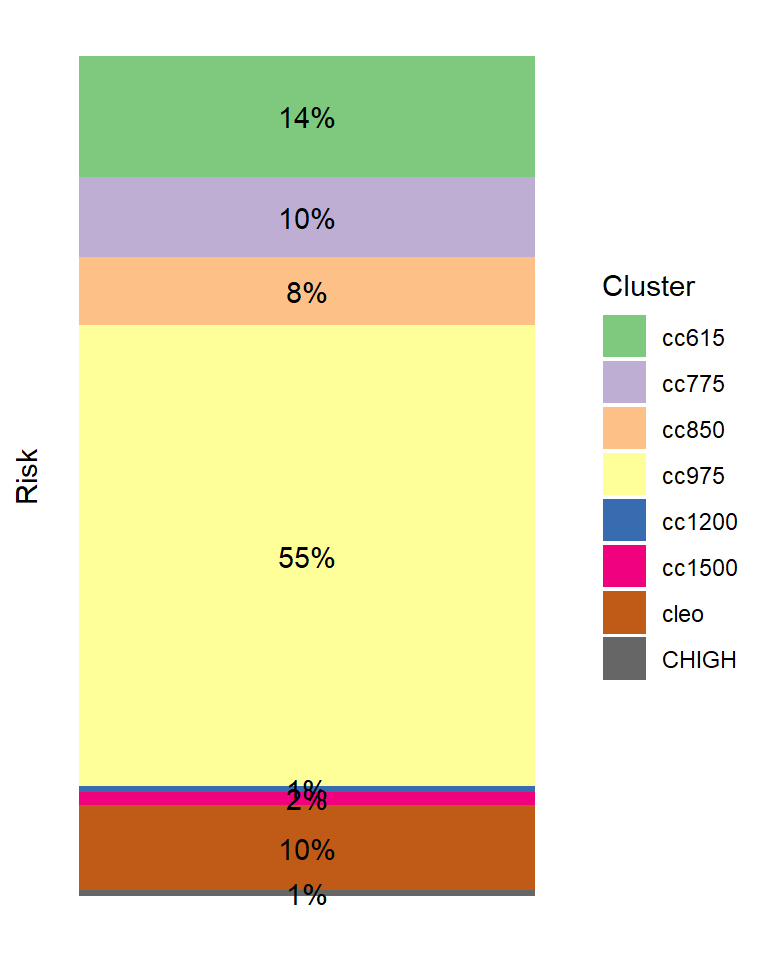

## Worst offender analysis– Method 2

The second method for calculating the top 50 statistically most concerning objects also uses the idea that risk = probability * consequence, although it slightly differs from the first method in what components make up probability and consequence.

Probability:

- CR = annual collision rate of each cluster
  - Each cluster of massive derelicts has an annual collision rate
- AR = cross-sectional area of object (estimated by multiplying mass by 0.005)
  - The larger cross-sectional area, the larger the likelihood of colliding
- E5 = number of encounters < 5 km per year
- E1 = number of encounters < 1 km per year

Consequence:

- MF = $\frac{mass~of~object}{1500}$
  - Mass is proportional to the amount of debris produced (mass ranges from 700-9000 kg)
  - Divide by 1500 so that objects below 1500 kg bring risk down while larger masses increase risk
- DF = $\frac{atmospheric~density ~at~ 500~km}{atmospheric~density~at ~object's ~avg. ~altitude}$
  - There’s a higher consequence for debris that linger for a longer amount of time, and orbital lifetime of resulting debris is proportional to atmospheric density (which decreases exponentially with increasing altitude).
  - Averaged across each cluster
- SD = spatial density of operational satellites
  - Consequence is higher when there are more operational satellites in the vacinity
  - Averaged across each cluster

Then for each object, the risk is calculated as:
$$Risk = [CR * AR * {E5/25 * (5 * E1)}] * [MF * DF * SD]$$

Summary of key measures per cluster:

| cluster | numDerelicts | avgMass | CR | DF | SD |
| --- | --- | --- | --- | --- | --- |
| cc615 | 165 | 1,847.1 | 1.5e-03 | 25 | 538 |
| cc775 | 154 | 1,574.1 | 1.4e-03 | 90 | 346 |
| cc850 | 97 | 3,257.9 | 2.4e-03 | 150 | 69 |
| cc975 | 355 | 1,176.4 | 8.2e-03 | 1,000 | 17 |
| cc1200 | 40 | 1,397.6 | 3.3e-05 | 1,600 | 26 |
| cc1500 | 73 | 1,311.4 | 1.2e-04 | 1,800 | 56 |
| cleo | 196 | 1,788.1 | 3.3e-04 | 150 | 103 |
| CHIGH | 188 | 3,028.8 | 2.5e-07 | 1,000 | 3 |

Note: values for CR, DF, and SD are used ona cluster level, meaning that all objects within a cluster have the same value for these three measures.

Top 50 statistically most concerning objects:

| noradId | name | cluster | SMC_risk | E5 | E1 | MF | DF | SD | CR | apogee | perigee | launch | inclination | mass | type | country |
| --- | --- | --- | --- | --- | --- | --- | --- | --- | --- | --- | --- | --- | --- | --- | --- | --- |
| 27006 | SL-16 R/B | cc975 | 2326154.78933333 | 158 | 2 | 5.93333333333333 | 1000 | 17 | 8.2e-03 | 1007 | 985 | 2001-12-10T00:00:00Z | 99.42 | 8900 | ROCKET BODY | CIS |
| 27001 | METEOR 3M | cc975 | 818975 | 141 | 10 | 1.66666666666667 | 1000 | 17 | 8.2e-03 | 1014 | 994 | 2001-12-10T00:00:00Z | 99.52 | 2500 | PAYLOAD | CIS |
| 14625 | SL-8 R/B | cc975 | 675361.5981984 | 186 | 19 | 0.956 | 1000 | 17 | 8.2e-03 | 1000 | 967 | 1984-01-11T00:00:00Z | 82.93 | 1434 | ROCKET BODY | CIS |
| 25407 | SL-16 R/B | cc850 | 432866.808 | 66 | 5 | 5.93333333333333 | 150 | 69 | 2.4e-03 | 844 | 835 | 1998-07-28T00:00:00Z | 71.01 | 8900 | ROCKET BODY | CIS |
| 31793 | SL-16 R/B | cc850 | 426308.22 | 65 | 5 | 5.93333333333333 | 150 | 69 | 2.4e-03 | 845 | 843 | 2007-06-29T00:00:00Z | 70.97 | 8900 | ROCKET BODY | CIS |
| 22220 | SL-16 R/B | cc850 | 409255.8912 | 52 | 6 | 5.93333333333333 | 150 | 69 | 2.4e-03 | 847 | 827 | 1992-11-17T00:00:00Z | 71 | 8900 | ROCKET BODY | CIS |
| 17974 | SL-16 R/B | cc850 | 373839.516 | 57 | 5 | 5.93333333333333 | 150 | 69 | 2.4e-03 | 846 | 824 | 1987-05-13T00:00:00Z | 71.01 | 8900 | ROCKET BODY | CIS |
| 10732 | SL-8 R/B | cc975 | 370741.794144 | 194 | 10 | 0.956 | 1000 | 17 | 8.2e-03 | 994 | 967 | 1978-03-15T00:00:00Z | 82.93 | 1434 | ROCKET BODY | CIS |
| 22285 | SL-16 R/B | cc850 | 346293.4464 | 66 | 4 | 5.93333333333333 | 150 | 69 | 2.4e-03 | 844 | 840 | 1992-12-25T00:00:00Z | 71.02 | 8900 | ROCKET BODY | CIS |
| 17290 | METEOR 2-15 | cc975 | 314486.4 | 94 | 9 | 1.33333333333333 | 1000 | 17 | 8.2e-03 | 957 | 936 | 1987-01-05T00:00:00Z | 82.47 | 2000 | PAYLOAD | CIS |

[output cut: 40 more lines]

### Risk among all derelicts

Among all derelicts, percent of risk accounted for by each cluster:

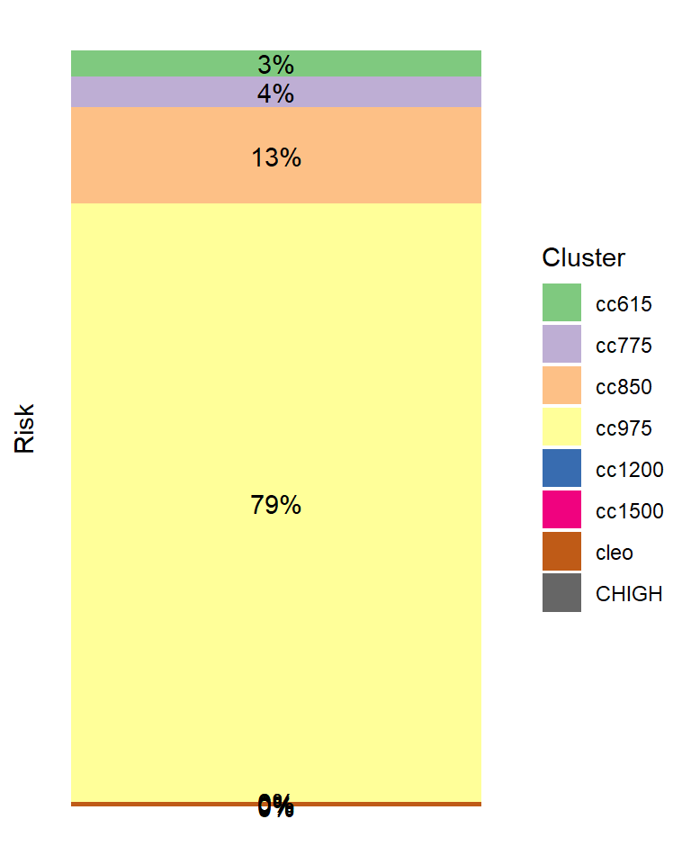